# Notes2_Practice

## Oxide Example

> Oxide Layer Thicknesses Example: (f):

```r
Thickness<-c(90.0, 92.2, 94.9, 92.7, 91.6, 88.2, 92.0, 98.2, 96.0, 91.1, 89.8, 91.5, 91.5, 90.6, 93.1, 88.9, 92.5, 92.4)
Thickness
```

```
##  [1] 90.0 92.2 94.9 92.7 91.6 88.2 92.0 98.2 96.0 91.1 89.8 91.5 91.5 90.6 93.1
## [16] 88.9 92.5 92.4
```

```r
length(Thickness)
```

```
## [1] 18
```

```r
sort(Thickness)
```

```
##  [1] 88.2 88.9 89.8 90.0 90.6 91.1 91.5 91.5 91.6 92.0 92.2 92.4 92.5 92.7 93.1
## [16] 94.9 96.0 98.2
```

```r
Thickness<-sort(Thickness, decreasing=FALSE)
#Thickness <-sort(Thickness , decreasing = TRUE)
Thickness
```

```
##  [1] 88.2 88.9 89.8 90.0 90.6 91.1 91.5 91.5 91.6 92.0 92.2 92.4 92.5 92.7 93.1
## [16] 94.9 96.0 98.2
```

> Oxide Layer Thicknesses Example (g): : Construct a dot plot, frequency histogram, relative frequency histogram, and density histogram for the oxide layer thicknesses data

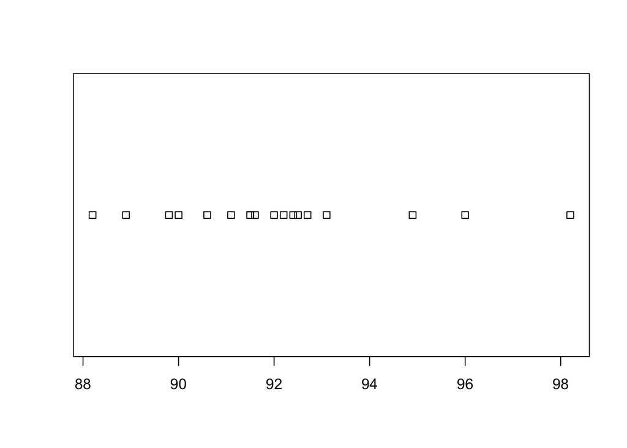

```r
#Dotplot
stripchart(Thickness)
```

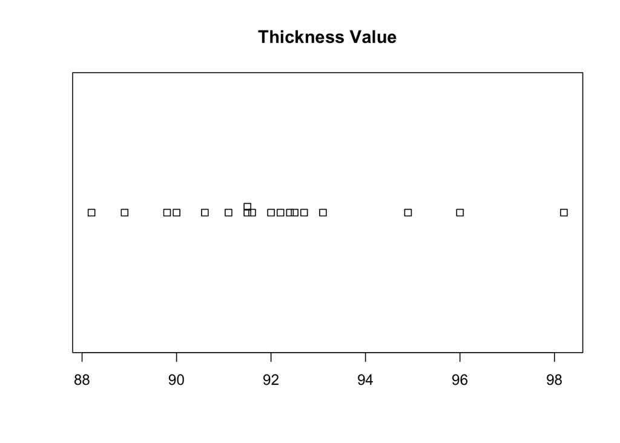

```r
stripchart(Thickness, method="stack", main="Thickness Value")
```

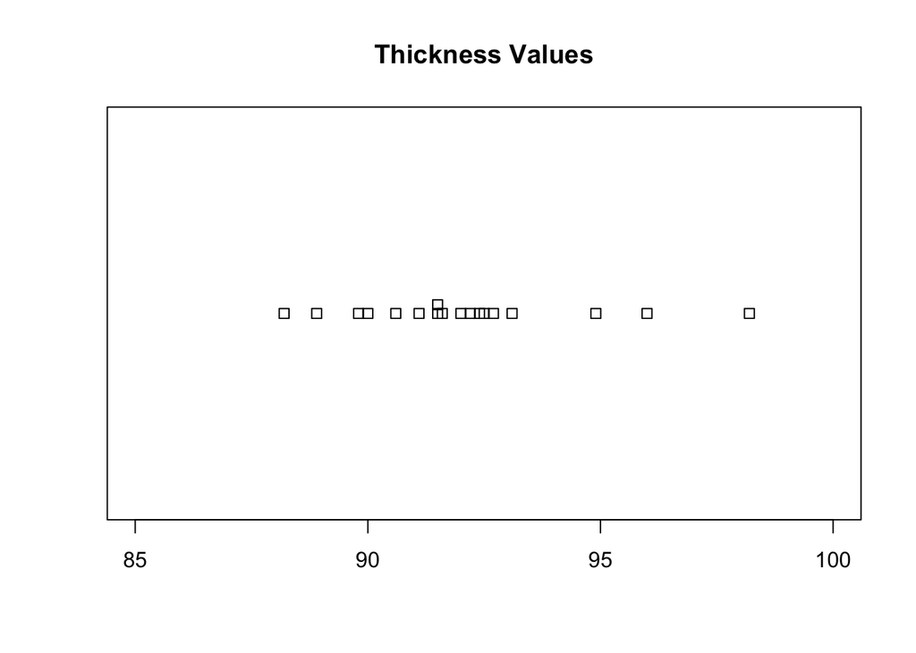

```r
stripchart(Thickness, method="stack", main="Thickness Values", xlim=c(85, 100))
```

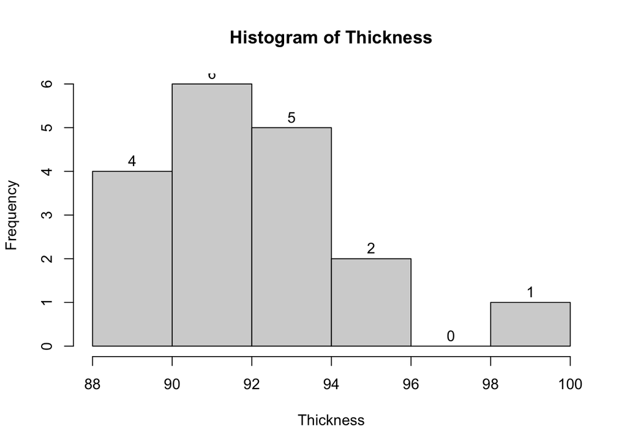

```r
#default hist is frequency and bins set for us
hist(Thickness)
hist(Thickness, labels=TRUE)
```

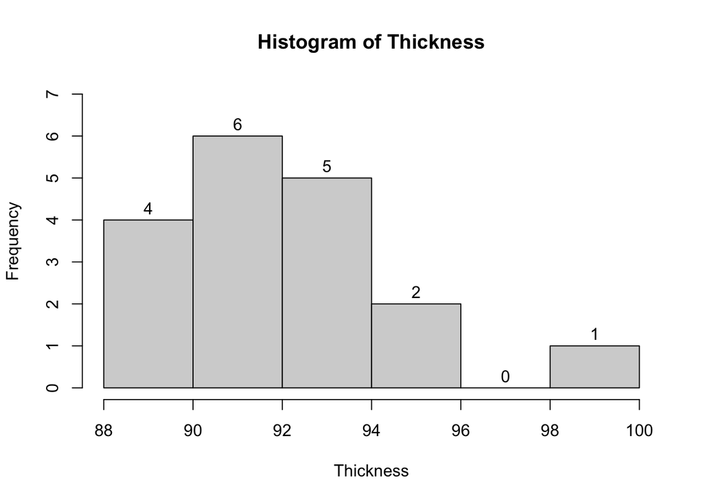

```r
hist(Thickness, labels=TRUE, ylim=c(0,7))
```

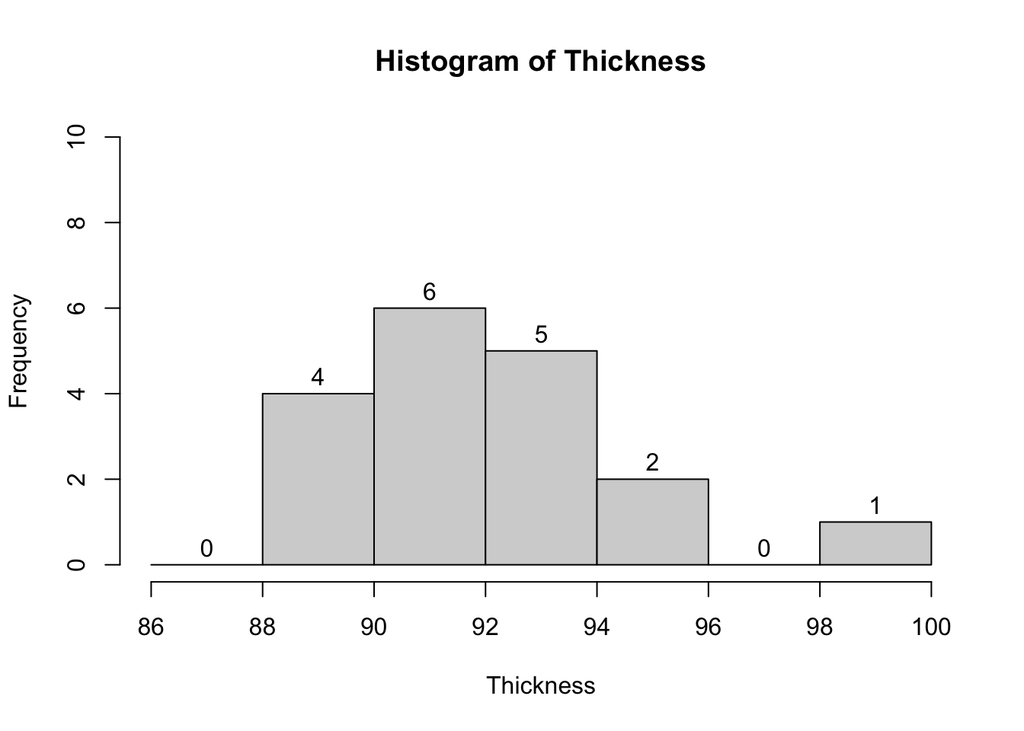

```r
hist(Thickness, breaks=seq(86,100,2), labels=TRUE, ylim=c(0,10))
```

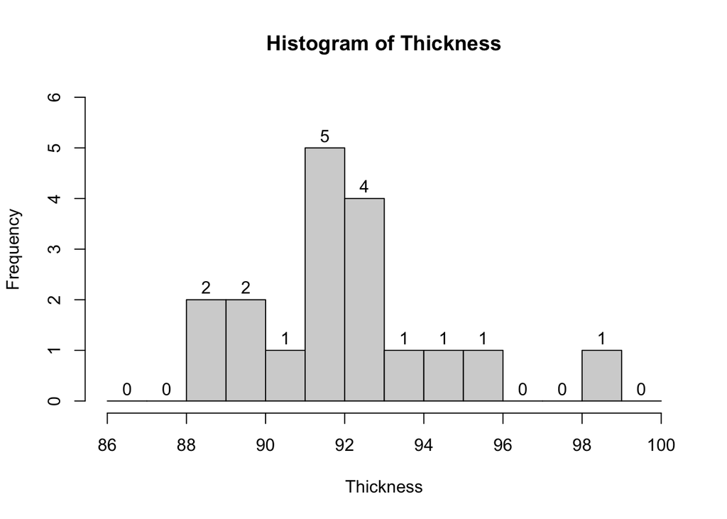

```r
hist(Thickness, breaks=seq(86,100,1), labels=TRUE, ylim=c(0,6))
```

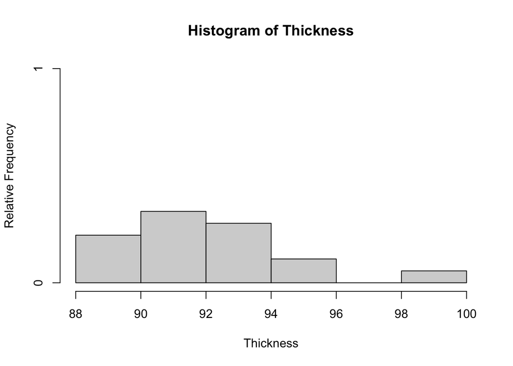

```r
#Relative freq hist
h<-hist(Thickness, plot=FALSE)
h$counts<-h$counts/length(Thickness)  #note: length(Thickness) is 18
plot(h, ylab="Relative Frequency", labels=FALSE, ylim=c(0,1))
```

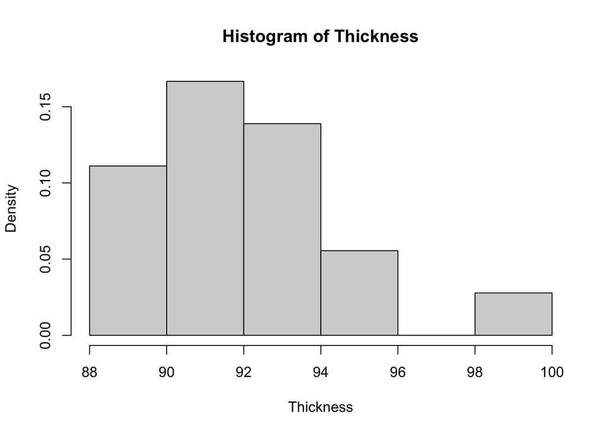

```r
#Density histogram will become more useful when we have data sets with a larger number of unique observations
hist(Thickness, freq=FALSE)
```

> Oxide Layer Thicknesses Example (i): Compute and compare the sample Mode, Mean, and Median of the observed thicknesses

```r
mean(Thickness) #92.06667
```

```
## [1] 92.06667
```

```r
sum(Thickness)/length(Thickness)  #1657.2/18 long hand
```

```
## [1] 92.06667
```

```r
median(Thickness)  #91.8
```

```
## [1] 91.8
```

> Oxide Layer Thicknesses (j): Compute the 1st, 2nd, and 3rd quartiles for thickness data. Interpret these values.

```r
quantile(Thickness, probs=c(.25, .5, .75))
```

```
##    25%    50%    75%
## 90.725 91.800 92.650
```

```r
quantile(Thickness, probs=c(0.25, .50, .75), type=2)  #type 7 is default, type=2 is SAS default
```

```
##  25%  50%  75%
## 90.6 91.8 92.7
```

> Oxide Layer Thicknesses Example (k): Compute and compare the range, IQR and Standard deviation for the thickness data. Interpret these values.

```r
range(Thickness)
```

```
## [1] 88.2 98.2
```

```r
IQR(Thickness, type=2)
```

```
## [1] 2.1
```

```r
quantile(Thickness, 0.75, type=2, names=FALSE)-quantile(Thickness, 0.25, type=2, names=FALSE)
```

```
## [1] 2.1
```

```r
mean(Thickness)
```

```
## [1] 92.06667
```

```r
sum((Thickness-mean(Thickness))^2) #sum of squared deviations
```

```
## [1] 101.24
```

```r
sqrt(sum((Thickness-mean(Thickness))^2)/17) #sample sd "long hand"
```

```
## [1] 2.440347
```

```r
sqrt(sum((Thickness-mean(Thickness))^2)/(length(Thickness)-1)) #sample sd "long hand"
```

```
## [1] 2.440347
```

```r
sd(Thickness) #sample sd
```

```
## [1] 2.440347
```

> Oxide Layer Thicknesses Example (l): Construct a boxplot for the thickness data

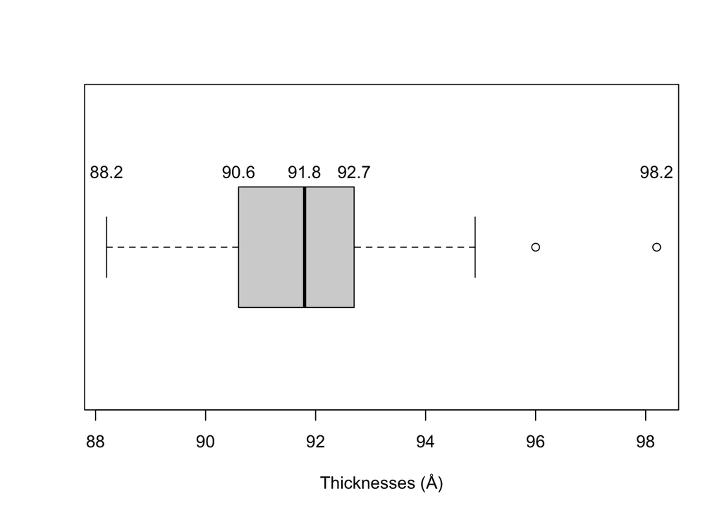

```r
boxplot(Thickness, horizontal=TRUE, xlab="Thicknesses (Å)")
text(x=fivenum(Thickness), labels=fivenum(Thickness), y=1.25)
```

```r
quantile(Thickness, type=2)
```

```
##   0%  25%  50%  75% 100%
## 88.2 90.6 91.8 92.7 98.2
```

> Oxide Layer Thicknesses m: Suppose the 98.2 had actually been recorded as 99.2. So the thickness values with the error are: 90.0, 92.2, 94.9, 92.7, 91.6, 88.2, 92.0, 99.2, 96.0, 91.1, 89.8, 91.5, 91.5, 90.6, 93.1, 88.9, 92.5, 92.4. How would Mean, Median, Range, IQR, and sample SD be affected by the error? How much would their value[s] change? How would the graphical summaries change?

```r
Thickness_Error<-c(90.0, 92.2, 94.9, 92.7, 91.6, 88.2, 92.0, 99.2, 96.0, 91.1, 89.8, 91.5, 91.5, 90.6, 93.1, 88.9, 92.5, 92.4)
# or by copying and editing the original vector
Thickness_Error2<-Thickness
Thickness_Error2[18]<-99.2
Thickness_Error2
```

```
##  [1] 88.2 88.9 89.8 90.0 90.6 91.1 91.5 91.5 91.6 92.0 92.2 92.4 92.5 92.7 93.1
## [16] 94.9 96.0 99.2
```

```r
mean(Thickness_Error) ; mean(Thickness_Error2)
```

```
## [1] 92.12222
```

```
## [1] 92.12222
```

```r
sum(Thickness_Error)  ; sum(Thickness_Error2)
```

```
## [1] 1658.2
```

```
## [1] 1658.2
```

```r
median(Thickness_Error)
```

```
## [1] 91.8
```

```r
quantile(Thickness_Error, type=2)
```

```
##   0%  25%  50%  75% 100%
## 88.2 90.6 91.8 92.7 99.2
```

```r
range(Thickness_Error)
```

```
## [1] 88.2 99.2
```

```r
sd(Thickness_Error)
```

```
## [1] 2.59469
```

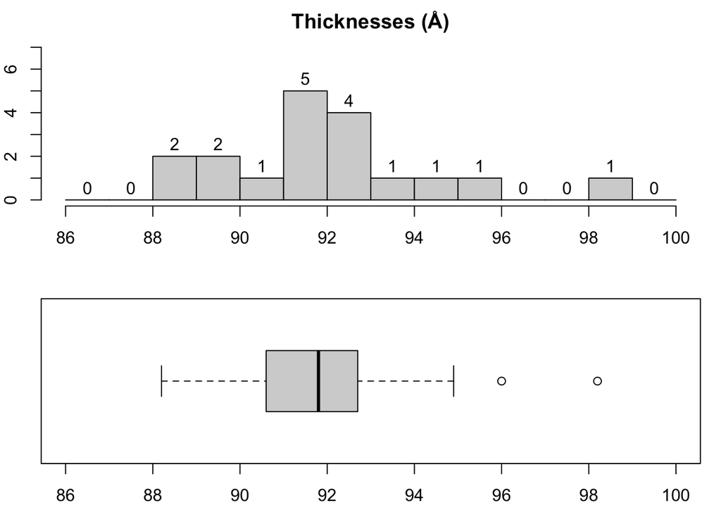

```r
#Graphs of correct data
par(mfrow=c(2,1), mar=c(2.5,2,2,1)) #This makes two rows of graphs in 1 column and sets the margins

hist(Thickness, labels=TRUE, ylim=c(0,7),
     breaks=seq(86,100,1), main="Thicknesses (Å)")
boxplot(Thickness, horizontal=TRUE, ylim=c(86,100))
```

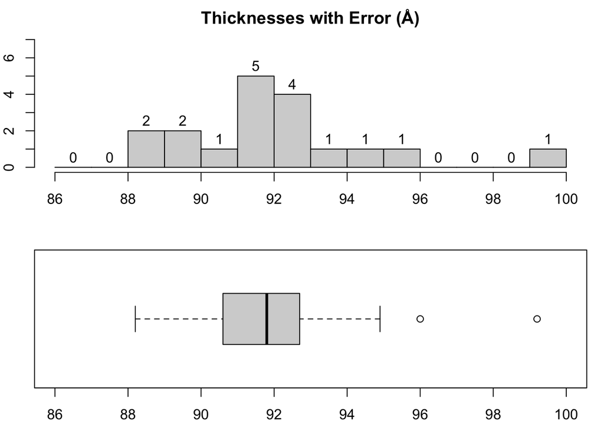

```r
#Graphs of data with error
hist(Thickness_Error, labels=TRUE, ylim=c(0,7),
     breaks=seq(86,100,1), main="Thicknesses with Error (Å)")
boxplot(Thickness_Error, horizontal=TRUE, ylim=c(86,100))
```

```r
par(mfrow=c(1,1), mar=c(5, 4.1, 4.1, 2.1)) #This resets the graphics window to 1 graph at a time and resets the margins
```

> Thickness Example (n): comparing 2 samples

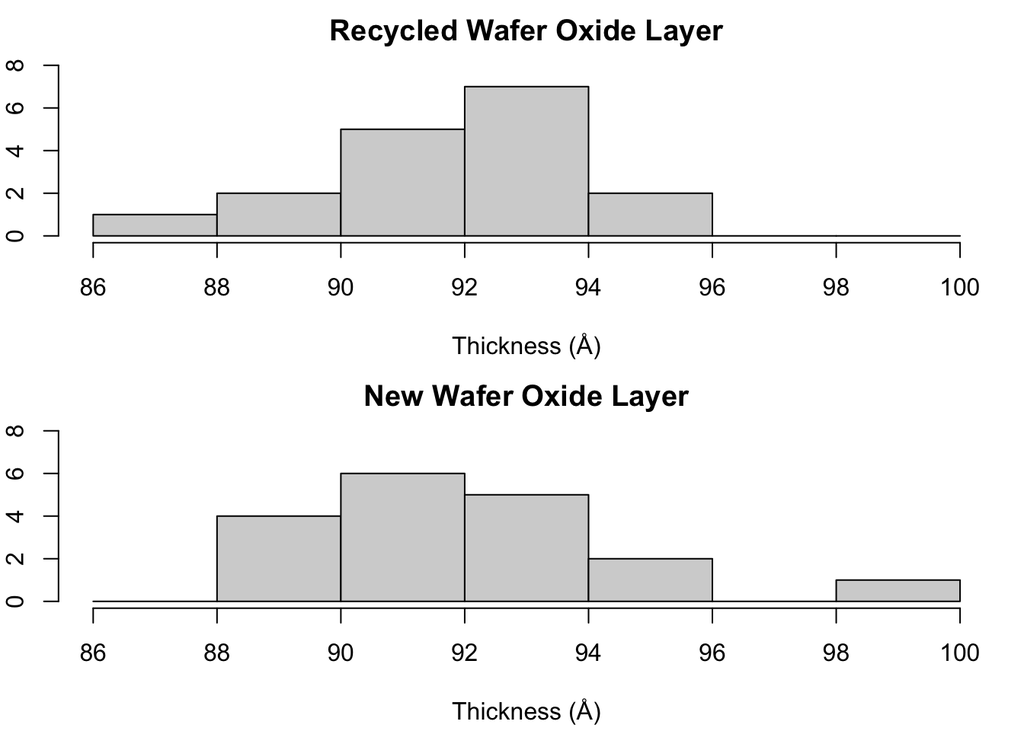

```r
Thickness_new<-Thickness
Thickness_rec<-c(91.8, 94.5, 93.9, 92.0, 89.9, 87.9, 92.8, 93.3, 92.6, 90.3, 92.8, 91.6, 92.7, 91.7, 89.3, 95.5, 93.6)

par(mfrow=c(2,1), mar=c(4.2,2,2,1))

hist(Thickness_rec, ylim=c(0,8),
     breaks=seq(86,100,2), main="Recycled Wafer Oxide Layer",
     xlab="Thickness (Å)")

hist(Thickness_new, ylim=c(0,8),
     breaks=seq(86, 100, 2), main="New Wafer Oxide Layer",
     xlab="Thickness (Å)")
```

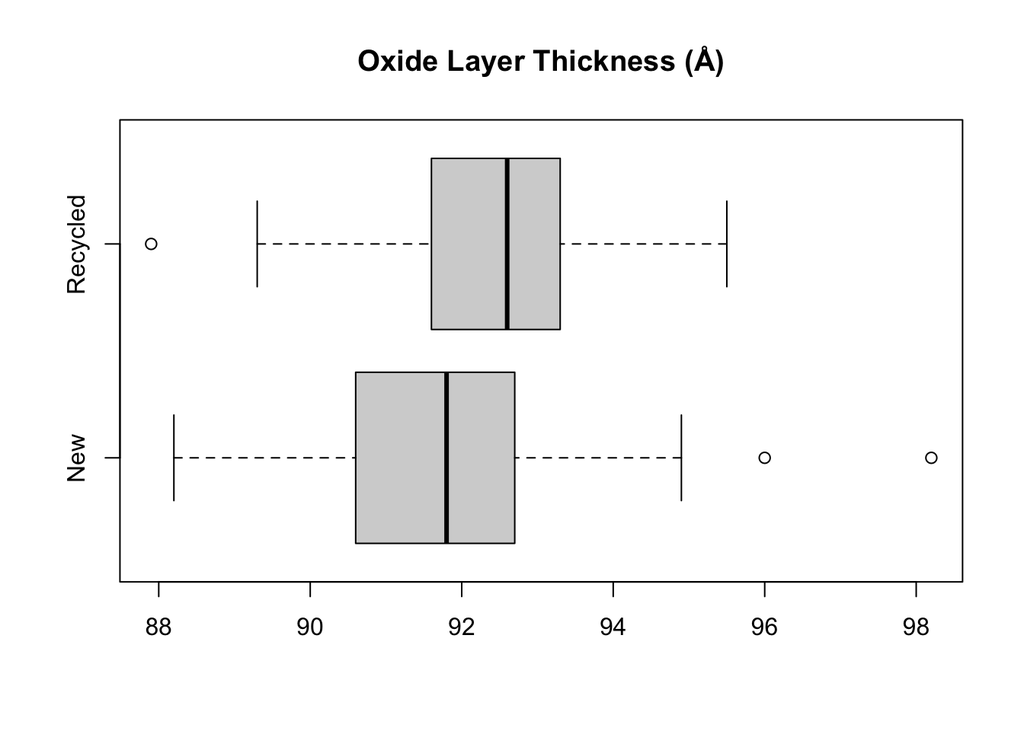

```r
par(mfrow=c(1,1), mar=c(5.1, 4.1, 4.1, 2.1))


boxplot(Thickness_new,Thickness_rec, horizontal=TRUE,
        names=c("New", "Recycled"),
        main="Oxide Layer Thickness (Å)")
```

```r
mean(Thickness_new); mean(Thickness_rec)
```

```
## [1] 92.06667
```

```
## [1] 92.12941
```

```r
median(Thickness_new); median(Thickness_rec)
```

```
## [1] 91.8
```

```
## [1] 92.6
```

```r
sd(Thickness_new); sd(Thickness_rec)
```

```
## [1] 2.440347
```

```
## [1] 1.934801
```

```r
IQR(Thickness_new, type=2); IQR(Thickness_rec, type=2)
```

```
## [1] 2.1
```

```
## [1] 1.7
```

> If Time: Thickness data from .csv file
> > 1. Navigate to folder that holds .Rmd and .csv file in Files pane
> > 2. Set folder in Files pane as working directory
> > 3. Read data into data frame using read.csv() command

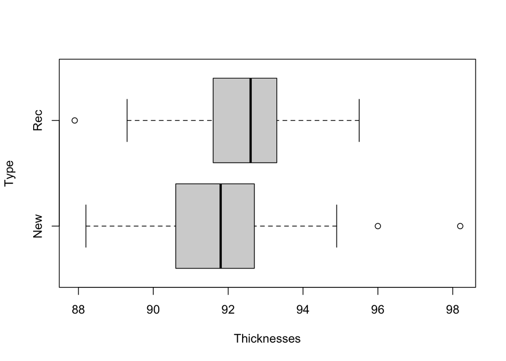

```r
#Thicknesses<-c(Thickness_new, Thickness_rec)
#Type=c(rep("New", times=18), rep("Rec", 17))
#Thickness_data<-data.frame(Type, Thicknesses)
#write.csv(Thickness_data, "Thickness_Data.csv")

Thickness_Data<-read.csv("Thickness_Data.csv")


#boxplot code works nicely
boxplot(Thicknesses~Type, data=Thickness_Data,
        horizontal=TRUE)
```

```r
#other summaries and graphs in base R require you save off the vectors of data separately

#this gets a dataframe and then vector of thicknesses for New Wafers
New_df<-subset(Thickness_Data, Type=="New")
Thick_new<-New_df$Thicknesses
mean(Thick_new); sd(Thick_new)
```

```
## [1] 92.06667
```

```
## [1] 2.440347
```

```r
#this gets a dataframe and then vector of thicknesses for Rec Wafers
Rec_df<-subset(Thickness_Data, Type=="Rec")
Thick_rec<-Rec_df$Thicknesses
mean(Thick_rec); sd(Thick_rec)
```

```
## [1] 92.12941
```

```
## [1] 1.934801
```

> Oxide Thickness example o: Summarize the observed sample according to the variable “Oxide Thickness Less than 90”

```r
Thickness<90
```

```
##  [1]  TRUE  TRUE  TRUE FALSE FALSE FALSE FALSE FALSE FALSE FALSE FALSE FALSE
## [13] FALSE FALSE FALSE FALSE FALSE FALSE
```

```r
sum(Thickness<90)  #3 Trues (1) 15 Falses (0)
```

```
## [1] 3
```

```r
sum(Thickness>=90)
```

```
## [1] 15
```

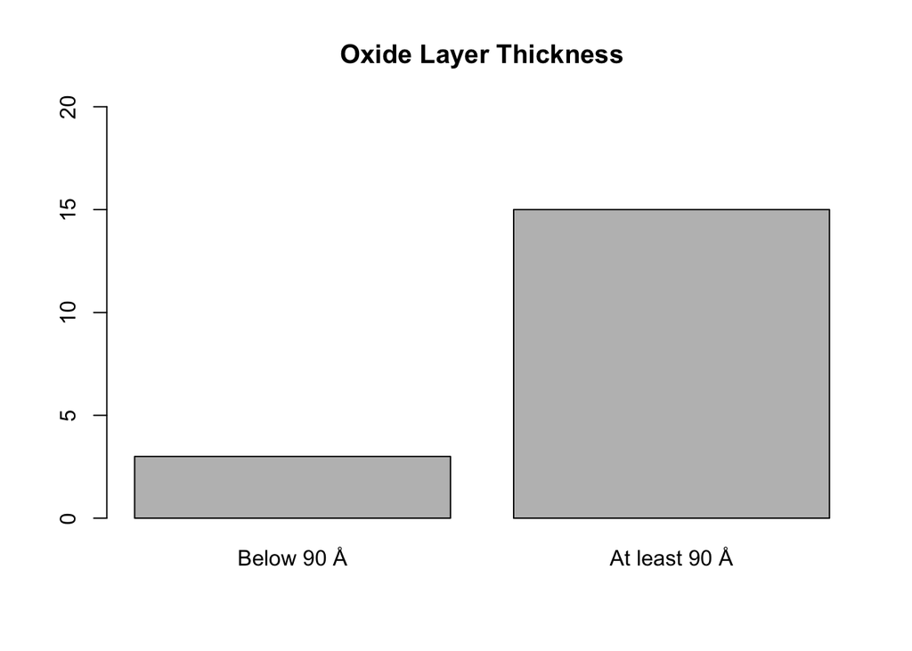

```r
barplot(height=c(3,15), names=c("Below 90 Å", "At least 90 Å"), ylim=c(0,20), main="Oxide Layer Thickness")
```

## Goverment Spending

> Gov Spending pie chart and bar chart.

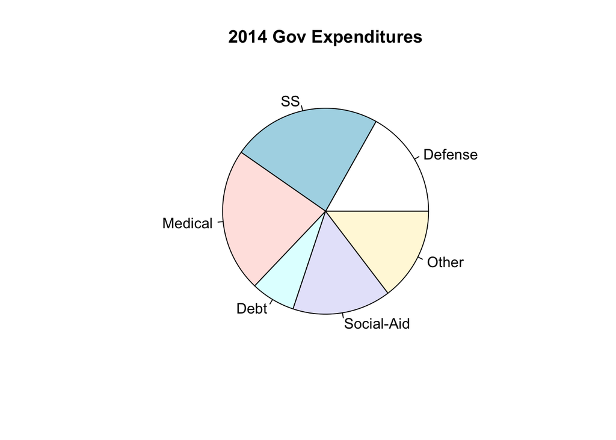

```r
Dollars<-c(612, 852, 821, 253, 562, 532)
#Pie Chart
pie(Dollars, labels=c("Defense", "SS", "Medical", "Debt", "Social-Aid", "Other"), main="2014 Gov Expenditures")
```

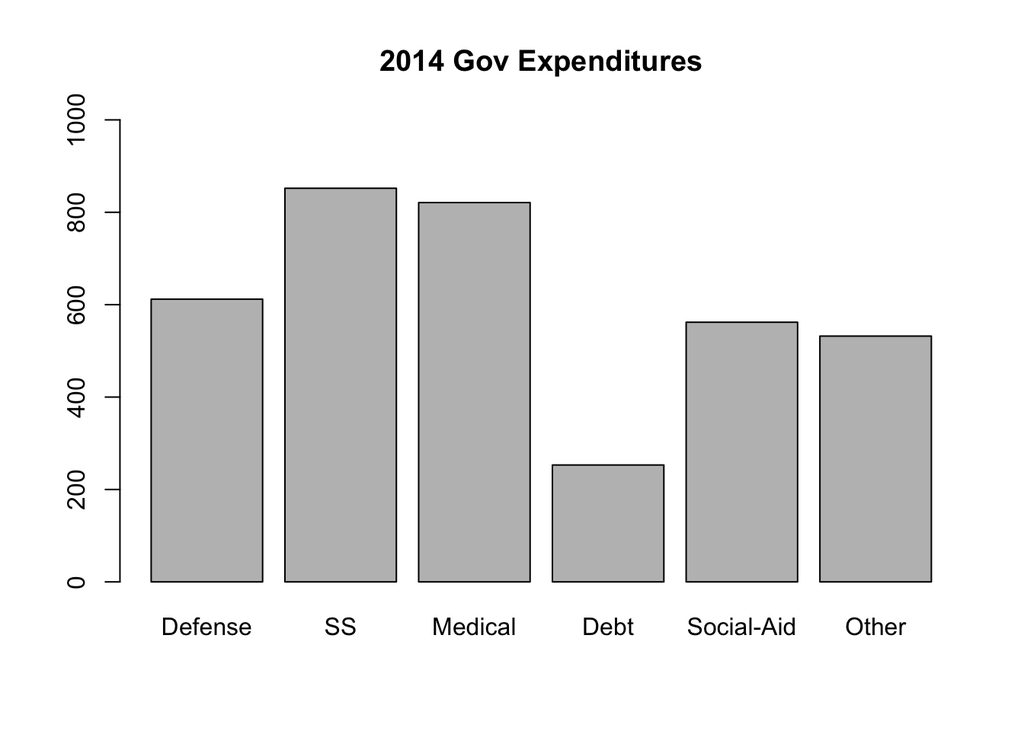

```r
#BarPlot
barplot(height=Dollars, names.arg=c("Defense", "SS", "Medical", "Debt", "Social-Aid", "Other"), main="2014 Gov Expenditures", ylim=c(0,1000))
```

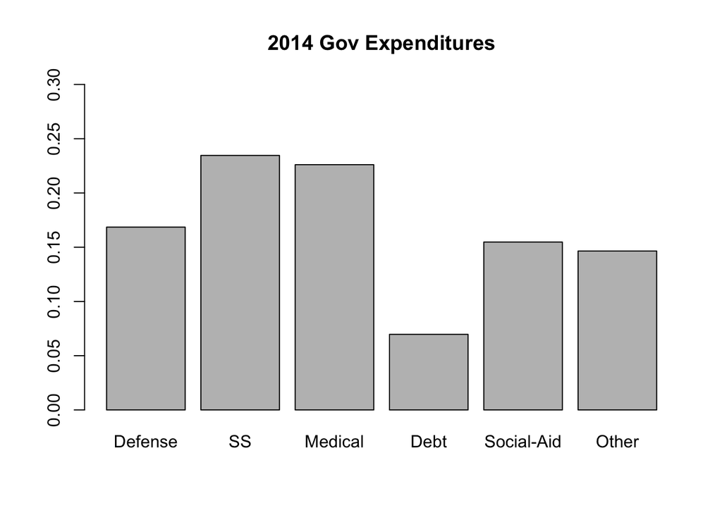

```r
barplot(height=Dollars/sum(Dollars), names.arg=c("Defense", "SS", "Medical", "Debt", "Social-Aid", "Other"), main="2014 Gov Expenditures", ylim=c(0,0.3))
```

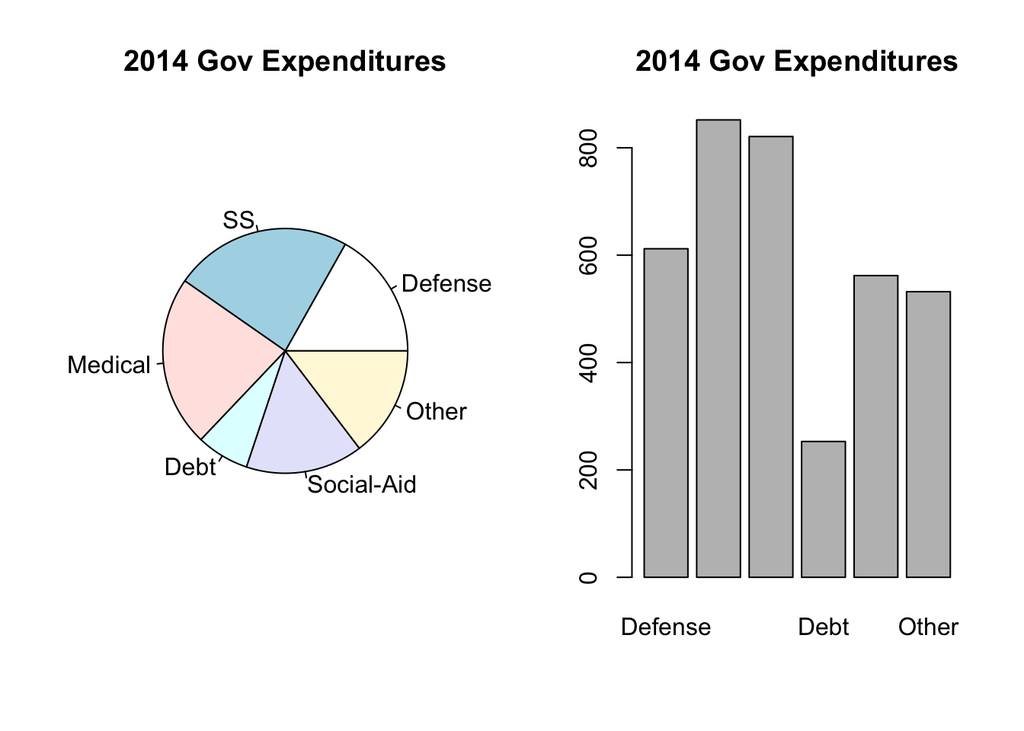

```r
par(mfrow=c(1,2))
pie(Dollars, labels=c("Defense", "SS", "Medical", "Debt", "Social-Aid", "Other"), main="2014 Gov Expenditures")

barplot(height=Dollars, names.arg=c("Defense", "SS", "Medical", "Debt", "Social-Aid", "Other"), main="2014 Gov Expenditures")
```

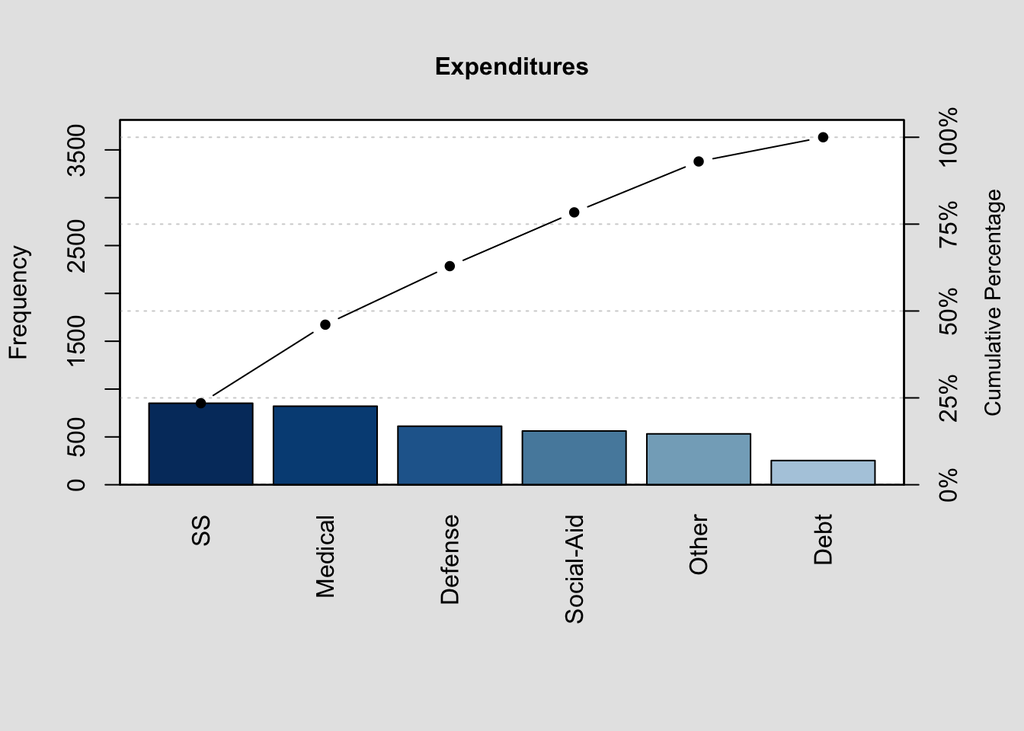

```
##
## Pareto chart analysis for Dollars
##                Frequency   Cum.Freq.  Percentage Cum.Percent.
##   SS          852.000000  852.000000   23.458150    23.458150
##   Medical     821.000000 1673.000000   22.604626    46.062775
##   Defense     612.000000 2285.000000   16.850220    62.912996
##   Social-Aid  562.000000 2847.000000   15.473568    78.386564
##   Other       532.000000 3379.000000   14.647577    93.034141
##   Debt        253.000000 3632.000000    6.965859   100.000000
```

```r
par(mfrow=c(1,1))

#Pareto Chart
#Dollars<-c(612, 852, 821, 253, 562, 532)
names(Dollars)<-c("Defense", "SS", "Medical", "Debt", "Social-Aid", "Other")

#Load pareto.chart() function from qcc package
#install.packages("qcc")
library(qcc)
pareto.chart(Dollars, main="Expenditures")
```